# Deepak_YouTube_Dataset_Solution

### 1. Import required libraries and read the provided dataset (youtube_dislike_dataset.csv) and retrieve top 5 and bottom 5 records.

```python
import pandas as pd
import numpy as np
```

```python
yt1 = pd.read_csv("E:\\PYTHON PROJECT\\Week-3 Project\\youtube_dislike_dataset.csv")
yt1.head(5)
```

|  | video_id | title | channel_id | channel_title | published_at | view_count | likes | dislikes | comment_count | tags | description | comments |
| --- | --- | --- | --- | --- | --- | --- | --- | --- | --- | --- | --- | --- |
| 0 | --0bCF-iK2E | Jadon Sancho Magical Skills & Goals | UC6UL29enLNe4mqwTfAyeNuw | Bundesliga | 2021-07-01 10:00:00 | 1048888 | 19515 | 226 | 1319 | football soccer ftbol alemn Bundesliga season ... | Enjoy the best skills and goals from Jadon San... | Respect to Dortmund fans,must be sad losing hi... |
| 1 | --14w5SOEUs | Migos - Avalanche (Official Video) | UCGIelM2Dj3zza3xyV3pL3WQ | MigosVEVO | 2021-06-10 16:00:00 | 15352638 | 359277 | 7479 | 18729 | Migos Avalanche Quality Control Music/Motown R... | Watch the the official video for Migos - "Aval... | Migos just makes me want to live my live to th... |
| 2 | --40TEbZ9Is | Supporting Actress in a Comedy: 73rd Emmys | UClBKH8yZRcM4AsRjDVEdjMg | Television Academy | 2021-09-20 01:03:32 | 925281 | 11212 | 401 | 831 |  | Hannah Waddingham wins the Emmy for Supporting... | Hannah's energy bursts through any screen. Wel... |
| 3 | --4tfbSyYDE | JO1'YOUNG (JO1 ver.)' PERFORMANCE VIDEO | UCsmXiDP8S40uBeJYxvyulmA | JO1 | 2021-03-03 10:00:17 | 2641597 | 39131 | 441 | 3745 | PRODUCE101JAPAN JO1 TheSTAR STA... | JO1'YOUNG (JO1 ver.)' PERFORMANCE VIDEO\n\n---... | youngVer>< REN is really PERFECT. It's not ju... |
| 4 | --DKkzWVh-E | Why Retaining Walls Collapse | UCMOqf8ab-42UUQIdVoKwjlQ | Practical Engineering | 2021-12-07 13:00:00 | 715724 | 32887 | 367 | 1067 | retaining wall New Jersey highway Direct Conne... | One of the most important (and innocuous) part... | Keep up with all my projects here: https://pr... |

```python
yt1.tail(5)
```

|  | video_id | title | channel_id | channel_title | published_at | view_count | likes | dislikes | comment_count | tags | description | comments |
| --- | --- | --- | --- | --- | --- | --- | --- | --- | --- | --- | --- | --- |
| 37417 | zzd4ydafGR0 | Lil Tjay - Calling My Phone (feat. 6LACK) [Off... | UCEB4a5o_6KfjxHwNMnmj54Q | Lil Tjay | 2021-02-12 05:03:49 | 120408275 | 2180780 | 35871 | 81360 | Lil Tjay Steady Calling My Phone Calling My Ph... | Official video for "Calling My Phone" by Lil T... | 'DESTINED 2 WIN' OUT NOW !! https://liltjay.ln... |
| 37418 | zziBybeSAtw | PELICANS at LAKERS \| FULL GAME HIGHLIGHTS \| Ja... | UCWJ2lWNubArHWmf3FIHbfcQ | NBA | 2021-01-16 05:39:05 | 2841917 | 20759 | 1049 | 2624 | NBA G League Basketball game-0022000187 Lakers... | PELICANS at LAKERS \| FULL GAME HIGHLIGHTS \| Ja... | Montrezl Harrell is going crazy with the rebou... |
| 37419 | zzk09ESX7e0 | [MV] (MAMAMOO) - Where Are We Now | UCuhAUMLzJxlP1W7mEk0_6lA | MAMAMOO | 2021-06-02 09:00:10 | 13346678 | 720854 | 4426 | 90616 | MAMAMOO WAW WAW MAMAMOO WAW Where Are We Now... | [MV] (MAMAMOO) - Where Are We Now\n\nInstagra... | I honestly do not know why this song hit so ha... |
| 37420 | zzmQEb0Em5I | FELLIPE ESCUDERO- Master Podcast #12 | UC8NjnNWMsRqq11NYvHAQb1g | Master Podcast | 2020-10-20 20:59:30 | 252057 | 19198 | 1234 | 1471 | master masterpodcast lord lord vinheteiro z z ... | DOCTOR HAIR\nhttps://www.thedoctorhair.com/?fb... | Foi um prazer passar esta tarde com vocs debat... |
| 37421 | zzxPZwaA-8w | Gareth Bale brace secures dramatic comeback on... | UCEg25rdRZXg32iwai6N6l0w | Tottenham Hotspur | 2021-05-23 21:00:31 | 2252090 | 34063 | 868 | 2004 | Spurs Tottenham Hotspur Tottenham Leicester ... | Two minute highlights from Tottenham Hotspur's... | Thank you Kane for everything you have given t... |

### 2. Check the info of the dataframe and write your inferences on data types and shape of the dataset.

```python
yt1.info()
```

```
<class 'pandas.core.frame.DataFrame'>
RangeIndex: 37422 entries, 0 to 37421
Data columns (total 12 columns):
 #   Column         Non-Null Count  Dtype
---  ------         --------------  -----
 0   video_id       37422 non-null  object
 1   title          37422 non-null  object
 2   channel_id     37422 non-null  object
 3   channel_title  37422 non-null  object
 4   published_at   37422 non-null  object
 5   view_count     37422 non-null  int64
 6   likes          37422 non-null  int64
 7   dislikes       37422 non-null  int64
 8   comment_count  37422 non-null  int64
 9   tags           37422 non-null  object
 10  description    37422 non-null  object
 11  comments       37264 non-null  object
dtypes: int64(4), object(8)
memory usage: 3.4+ MB
```

**The dataset consists of 37,422 rows and 12 columns in total. Four of these columns are of integer type (int64) and remaining eight columns are of object type (object).**

### 3. Check for the Percentage of the missing values and drop or impute them.

```python
yt1.isnull().sum()/len(yt1)*100
```

```
video_id         0.000000
title            0.000000
channel_id       0.000000
channel_title    0.000000
published_at     0.000000
view_count       0.000000
likes            0.000000
dislikes         0.000000
comment_count    0.000000
tags             0.000000
description      0.000000
comments         0.422212
dtype: float64
```

**This indicates there are only one column has missing values in these columns.The comments column has 37,264 non-null entries, suggesting there are some missing values percentage are 0.42% (158 to be exact).**

```python
# we have to make a copy data to Analyse father
yt = yt1.copy()
```

```python
# we are droping "comments" column.
yt.drop(['comments'],axis=1,inplace=True)
```

```python
yt.isnull().sum()
```

```
video_id         0
title            0
channel_id       0
channel_title    0
published_at     0
view_count       0
likes            0
dislikes         0
comment_count    0
tags             0
description      0
dtype: int64
```

```python
yt.info()
```

```
<class 'pandas.core.frame.DataFrame'>
RangeIndex: 37422 entries, 0 to 37421
Data columns (total 11 columns):
 #   Column         Non-Null Count  Dtype
---  ------         --------------  -----
 0   video_id       37422 non-null  object
 1   title          37422 non-null  object
 2   channel_id     37422 non-null  object
 3   channel_title  37422 non-null  object
 4   published_at   37422 non-null  object
 5   view_count     37422 non-null  int64
 6   likes          37422 non-null  int64
 7   dislikes       37422 non-null  int64
 8   comment_count  37422 non-null  int64
 9   tags           37422 non-null  object
 10  description    37422 non-null  object
dtypes: int64(4), object(7)
memory usage: 3.1+ MB
```

### 4. Check the statistical summary of both numerical and categorical columns and write your inferences.

```python
yt.describe()
```

|  | view_count | likes | dislikes | comment_count |
| --- | --- | --- | --- | --- |
| count | 3.742200e+04 | 3.742200e+04 | 3.742200e+04 | 3.742200e+04 |
| mean | 5.697838e+06 | 1.668147e+05 | 4.989862e+03 | 9.924930e+03 |
| std | 2.426622e+07 | 5.375670e+05 | 3.070824e+04 | 1.171003e+05 |
| min | 2.036800e+04 | 0.000000e+00 | 0.000000e+00 | 0.000000e+00 |
| 25% | 5.122970e+05 | 1.323350e+04 | 2.810000e+02 | 9.000000e+02 |
| 50% | 1.319078e+06 | 4.233050e+04 | 7.960000e+02 | 2.328000e+03 |
| 75% | 3.670231e+06 | 1.304698e+05 | 2.461750e+03 | 6.184000e+03 |
| max | 1.322797e+09 | 3.183768e+07 | 2.397733e+06 | 1.607103e+07 |

- **View Count:**

*Mean: Approximately 5,6 million views per video. High standard deviation 2.42 indicates a wide distribution in the number of views, suggesting that some videos are extremely popular while others are not. The maximum view count is significantly high around 1.3 billion, which could be an outlier or indicative of viral videos.*

- **Dislikes:**

*Mean: About 4,989 dislikes per video. Again, a high standard deviation 3.070 indicates varied audience reception. Videos with zero dislikes are present, indicating possible new or less-viewed content.*

- **Comment Count:**

*Mean: Approximately 9,924 comments per video. A high standard deviation 1.171 suggests that some videos generate a lot of discussions, while others do not. The presence of videos with zero comments might indicate disabled comment sections or low engagement.*

```python
yt.describe(include=object)
```

|  | video_id | title | channel_id | channel_title | published_at | tags | description |
| --- | --- | --- | --- | --- | --- | --- | --- |
| count | 37422 | 37422 | 37422 | 37422 | 37422 | 37422 | 37422 |
| unique | 37422 | 37113 | 10961 | 10883 | 36772 | 28799 | 35630 |
| top | --0bCF-iK2E | www | UCNAf1k0yIjyGu3k9BwAg3lg | Sky Sports Football | 2020-10-16 04:00:10 |  |  |
| freq | 1 | 21 | 533 | 533 | 6 | 3817 | 589 |

- **Video_id:**

*Each video has a unique identifier, as indicated by the equal count and unique values.*

- **Channel_id and Channel_title:**

_There are 10,961 unique channel_id and 10,883 unique channel*titles, suggesting most channels have unique titles. A single channel ('UCNAf1k0yIjyGu3k9BwAg3lg', titled 'Sky Sports Football') dominates in frequency, indicating that good content output or a popular channel in the dataset.*

- **Published_at:**

*Indicates when videos were published. The most common date is '2020-10-16 04:00:10', which could be a significant date for the dataset (perhaps due to a specific event or data collection method).*

- **Tags and Description:**

*A wide variety of tags and descriptions are used, with the most frequent tag being used 3,817 times. The diversity in tags and descriptions reflects the variety of content and most frequent descriptions being used 589 times.*

### 5. Convert datatype of column published_at from object to pandas datetime.

```python
yt['published_at'] = pd.to_datetime(yt['published_at'])
```

```python
yt.info()
```

```
<class 'pandas.core.frame.DataFrame'>
RangeIndex: 37422 entries, 0 to 37421
Data columns (total 11 columns):
 #   Column         Non-Null Count  Dtype
---  ------         --------------  -----
 0   video_id       37422 non-null  object
 1   title          37422 non-null  object
 2   channel_id     37422 non-null  object
 3   channel_title  37422 non-null  object
 4   published_at   37422 non-null  datetime64[ns]
 5   view_count     37422 non-null  int64
 6   likes          37422 non-null  int64
 7   dislikes       37422 non-null  int64
 8   comment_count  37422 non-null  int64
 9   tags           37422 non-null  object
 10  description    37422 non-null  object
dtypes: datetime64[ns](1), int64(4), object(6)
memory usage: 3.1+ MB
```

### 6. Create a new column as 'published_month' using the column published_at (display the months only)

```python
yt['published_month'] = yt['published_at'].dt.month
yt.head(3)
```

[output not shown]

### 7. Replace the numbers in the column published_month as names of the months i,e., 1 as 'Jan', 2 as 'Feb'and so on.....

```python
# Mapping of month numbers to month names
month = {
    1: 'Jan', 2: 'Feb', 3: 'Mar', 4: 'Apr', 5: 'May', 6: 'Jun',
    7: 'Jul', 8: 'Aug', 9: 'Sep', 10: 'Oct', 11: 'Nov', 12: 'Dec'
}

# Replace the numbers in 'published_month' with month names
yt['published_month'] = yt['published_month'].map(month)
```

```python
yt.head(3)
```

|  | video_id | title | channel_id | channel_title | published_at | view_count | likes | dislikes | comment_count | tags | description | published_month |
| --- | --- | --- | --- | --- | --- | --- | --- | --- | --- | --- | --- | --- |
| 0 | --0bCF-iK2E | Jadon Sancho Magical Skills & Goals | UC6UL29enLNe4mqwTfAyeNuw | Bundesliga | 2021-07-01 10:00:00 | 1048888 | 19515 | 226 | 1319 | football soccer ftbol alemn Bundesliga season ... | Enjoy the best skills and goals from Jadon San... | Jul |
| 1 | --14w5SOEUs | Migos - Avalanche (Official Video) | UCGIelM2Dj3zza3xyV3pL3WQ | MigosVEVO | 2021-06-10 16:00:00 | 15352638 | 359277 | 7479 | 18729 | Migos Avalanche Quality Control Music/Motown R... | Watch the the official video for Migos - "Aval... | Jun |
| 2 | --40TEbZ9Is | Supporting Actress in a Comedy: 73rd Emmys | UClBKH8yZRcM4AsRjDVEdjMg | Television Academy | 2021-09-20 01:03:32 | 925281 | 11212 | 401 | 831 |  | Hannah Waddingham wins the Emmy for Supporting... | Sep |

### 8. Find the number of videos published each month and arrange the months in a decreasing order based on the video count.

```python
pd.pivot_table(data=yt,index='published_month',values='view_count',aggfunc='count').sort_values('view_count',ascending=False)
```

| published_month | view_count |
| --- | --- |
| Oct | 4991 |
| Sep | 4880 |
| Nov | 4851 |
| Aug | 4262 |
| Dec | 3072 |
| Jul | 2340 |
| Jun | 2316 |
| Mar | 2258 |
| Feb | 2137 |
| Apr | 2126 |
| Jan | 2108 |
| May | 2081 |

**The number of video uploads shows a pattern of rising and falling over the months, with higher counts in autumn (October, September, November), a moderate level in August and December, and lower counts in mid-year and early months.**

### 9. Find the count of unique video_id, channel_id and channel_title.

```python
yt[['video_id','channel_id','channel_title']].nunique()
```

```
video_id         37422
channel_id       10961
channel_title    10883
dtype: int64
```

### 10. Find the top10 channel names having the highest number of videos in the dataset and the bottom10 having lowest number of videos.

```python
yt['channel_title'].value_counts().head(10)
```

```
channel_title
Sky Sports Football    533
The United Stand       301
BT Sport               246
NBA                    209
NFL                    162
WWE                    122
SSSniperWolf            99
SSundee                 98
FORMULA 1               87
NHL                     86
Name: count, dtype: int64
```

```python
yt['channel_title'].value_counts().tail(10)
```

```
channel_title
Eiaz                     1
adidas                   1
Universitetet i Agder    1
Team Tapia               1
TheVincentMottola        1
Blocktrainer             1
Movie Addicts            1
1 1 minute mom           1
FLORIN CERCEL            1
Master Podcast           1
Name: count, dtype: int64
```

### 11. Find the title of the video which has the maximum number of likes and the title of the video having minimum likes and write your inferences.

```python
pd.DataFrame(yt.loc[yt['likes'].idxmax()]).T
```

|  | video_id | title | channel_id | channel_title | published_at | view_count | likes | dislikes | comment_count | tags | description | published_month |
| --- | --- | --- | --- | --- | --- | --- | --- | --- | --- | --- | --- | --- |
| 26143 | gdZLi9oWNZg | BTS () 'Dynamite' Official MV | UC3IZKseVpdzPSBaWxBxundA | HYBE LABELS | 2020-08-21 03:58:10 | 1322796924 | 31837675 | 1814333 | 16071029 | BIGHIT BTS BANGTAN | BTS () 'Dynamite' Official MV\n\n\nCredits:\nD... | Aug |

- **Video Title: BTS () 'Dynamite' Official MV**
- **Likes: 31,837,675**

*This indicates that the BTS music video "Dynamite" has received the maximum number of likes among the provided videos, highlighting its immense popularity on YouTube.*

```python
pd.DataFrame(yt.loc[yt['likes'].idxmin()]).T
```

|  | video_id | title | channel_id | channel_title | published_at | view_count | likes | dislikes | comment_count | tags | description | published_month |
| --- | --- | --- | --- | --- | --- | --- | --- | --- | --- | --- | --- | --- |
| 18654 | Uh-lqtF2yO8 | Kim Kardashian's Must-See Moments on "Saturday... | UCjDsbbzHgTrGc4Ff26TJtsA | E! News | 2021-10-10 08:36:34 | 403616 | 0 | 0 | 0 | E! NEWS NOW WOCHIT CELEBRITIES TOP STORIES TOP... | Kim Kardashian takes her @Saturday Night Live ... | Oct |

- **Video Title: Kim Kardashian's Must-See Moments on "Saturday Night Live" | E! News**
- **Likes: 0**

*The video "Kim Kardashian's Must-See Moments on 'Saturday Night Live'" has received the minimum number of likes, suggesting either a lack of content or possibly a newer video that hasn't garnered much attention.*

### 12. Find the title of the video which has the maximum number of dislikes and the title of the video having minimum dislikes and write your inferences.

```python
pd.DataFrame(yt.loc[yt['dislikes'].idxmax()]).T
```

|  | video_id | title | channel_id | channel_title | published_at | view_count | likes | dislikes | comment_count | tags | description | published_month |
| --- | --- | --- | --- | --- | --- | --- | --- | --- | --- | --- | --- | --- |
| 13591 | M0O7lLe4SmA | Cuties \| Official Trailer \| Netflix | UCWOA1ZGywLbqmigxE4Qlvuw | Netflix | 2020-08-18 14:00:00 | 17996395 | 94569 | 2397733 | 205009 | Cuties Mignonnes Netflix NetflixFilm Dance Mai... | Eleven-year-old Amy starts to rebel against he... | Aug |

- **Title: "Cuties | Official Trailer | Netflix"**
- **Dislikes: 2,397,733**

*The video titled "Cuties | Official Trailer | Netflix" has the highest number of dislikes, indicating that this particular content received a significant amount of negative feedback.*

```python
pd.DataFrame(yt.loc[yt['dislikes'].idxmin()]).T
```

|  | video_id | title | channel_id | channel_title | published_at | view_count | likes | dislikes | comment_count | tags | description | published_month |
| --- | --- | --- | --- | --- | --- | --- | --- | --- | --- | --- | --- | --- |
| 18654 | Uh-lqtF2yO8 | Kim Kardashian's Must-See Moments on "Saturday... | UCjDsbbzHgTrGc4Ff26TJtsA | E! News | 2021-10-10 08:36:34 | 403616 | 0 | 0 | 0 | E! NEWS NOW WOCHIT CELEBRITIES TOP STORIES TOP... | Kim Kardashian takes her @Saturday Night Live ... | Oct |

- **Title: "Kim Kardashian's Must-See Moments on 'Saturday Night Live' | E! News"**
- **Dislikes: 0**

*The video titled "Kim Kardashian's Must-See Moments on 'Saturday Night Live' | E! News" has the minimum dislikes, suggesting that this content did not generate a substantial amount of negative reactions or possibly a newer video that hasn't garnered much attention.*

### 13. Does the number of views have any effect on how many people disliked the video? Support your answer with a metric and a plot.

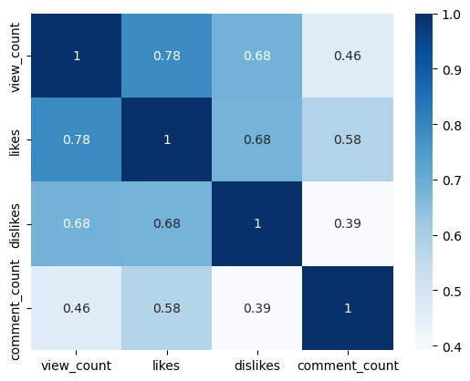

```python
sns.heatmap(yt.select_dtypes(include ='number').corr(),annot=True, cmap= 'Blues')
```

```python
yt['view_count'].corr(yt['dislikes'])
```

```
0.6844687753905547
```

The correlation coefficient between view_count and dislikes dataset is 0.6845. This value indicates a moderate to strong positive correlation.The data suggests that, generally, as the number of views on a video increases, the number of dislikes also tends to increase.

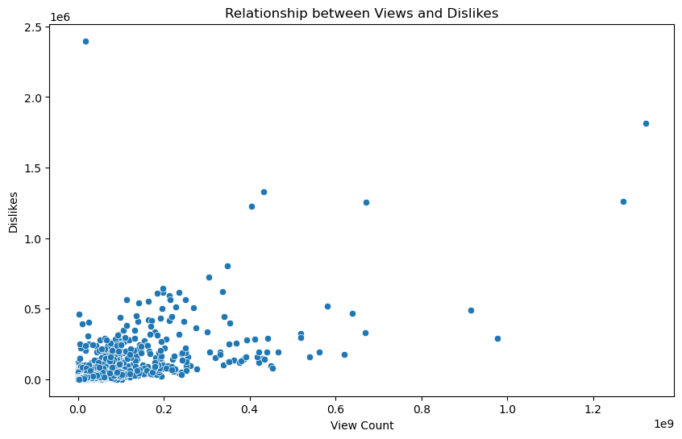

```python
import matplotlib.pyplot as plt
import seaborn as sns
import warnings
warnings.filterwarnings('ignore')

plt.figure(figsize=(10, 6))
sns.scatterplot(x='view_count', y='dislikes', data=yt)
plt.title('Relationship between Views and Dislikes')
plt.xlabel('View Count')
plt.ylabel('Dislikes')
plt.show()
```

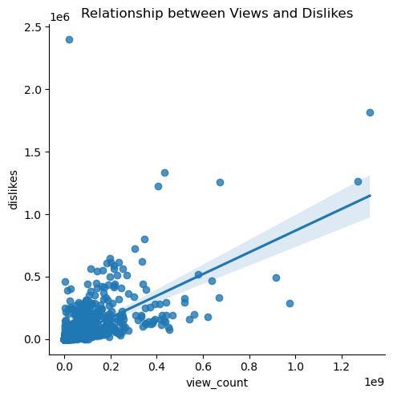

```python
plt.figure(figsize=(15, 6))
sns.lmplot(data=yt, x='view_count', y='dislikes')
plt.title('Relationship between Views and Dislikes')
plt.show()
```

**There appears to be a moderately strong positive correlation(0.6) between these two variables, indicating that videos with higher view counts tend to have a higher number of dislikes. As a video's popularity grows, evidenced by an increase in views, it tends to attract a greater number of dislikes.The plot suggests that higher visibility of videos might lead to more dislikes.**

### 14. Display all the information about the videos that were published in January, and mention the count of videos that were published in January.

```python
Jan = yt.query('published_month=="Jan"')
Jan
```

|  | video_id | title | channel_id | channel_title | published_at | view_count | likes | dislikes | comment_count | tags | description | published_month |
| --- | --- | --- | --- | --- | --- | --- | --- | --- | --- | --- | --- | --- |
| 27 | -2Gwm7QfBnE | Q&A With Naisha | UCYwNMbogQFzMccPSuy-pPWg | MianTwins | 2021-01-21 00:05:47 | 872372 | 38626 | 239 | 621 |  | Hey Guys!!! this has been the most requested v... | Jan |
| 48 | -4sfXSHSxzA | SURPRISING BRENT WITH HIS TIKTOK CRUSH!! | UCPpATKqmMV-CNRNWYaDUwiA | Alexa Rivera | 2021-01-16 21:40:04 | 6504784 | 262477 | 5779 | 7907 |  | He had no idea! Thank you guys so much for wat... | Jan |
| 95 | -AJD1Fc5rpQ | WE ARE HAVING A BABY! \| finding out i'm pregna... | UCVsTboAhpnuL6j-tDePvNwQ | Tess Christine | 2021-01-03 21:53:48 | 533084 | 38965 | 119 | 1650 |  | I am so happy to tell you that I am pregnant!!... | Jan |
| 103 | -AuJiwjsmWk | Do Ugly Foods Taste Worse? Taste Test | UCzpCc5n9hqiVC7HhPwcIKEg | Good Mythical MORE | 2021-01-19 11:00:01 | 1057077 | 22526 | 531 | 773 | gmm good mythical morning rhettandlink rhett a... | Today, we're doing a blind taste test to deter... | Jan |
| 182 | -JhqO2KWr5U | Schlatt gets fit | UCWZp4y1jqBuvLtiyxSs_ZBw | Big guy | 2021-01-24 22:50:57 | 1724965 | 119431 | 325 | 1578 | jschlatt big guy jschlatt highlights schlatt j... | #jschlatt #schlatt #bigguy #short | Jan |
| ... | ... | ... | ... | ... | ... | ... | ... | ... | ... | ... | ... | ... |
| 37300 | zmzFL5bG-jc | DEVINE MON PERSONNAGE AVANT AKINATOR ! (c'est ... | UCIlr3byh6wmXgcPx_Tm9Ocw | Piwerre | 2021-01-16 16:12:19 | 670357 | 54462 | 832 | 1249 | Piwerre frere de michou crouton among us devin... | Discord Piwerre : https://discord.gg/QBduPgAA... | Jan |
| 37329 | zpzjex7qwrA | Lampard Sacked Within Days Rorys Misery \| Chel... | UCkD-ZOixI0a9FjIExDsHsbg | The Kick Off | 2021-01-03 20:13:49 | 428646 | 12060 | 296 | 1505 | Premier league Chelsea chelsea 1-3 Man City Ch... | The Kick Off watched Manchester City destroy C... | Jan |
| 37345 | zqyv-B6mnBM | Lil Wayne - Ain't Got Time (Audio) | UCO9zJy7HWrIS3ojB4Lr7Yqw | Lil Wayne | 2021-01-21 05:00:10 | 2238244 | 58925 | 2365 | 5539 | lil wayne weezy weezy wednesday wayne carter y... | Official audio for Lil Wayne "Ain't Got Time",... | Jan |
| 37383 | zwfu1-24T7Q | PRADA Cup Day 1 \| Full Race Replay \| PRADA Cup... | UCo15ZYO_XDRU9LI30OPtxAg | America's Cup | 2021-01-15 04:07:55 | 317382 | 2008 | 83 | 192 | America's Cup Americas Cup AC36 AC75 Presented... | The opening day of the PRADA Cup in Auckland, ... | Jan |
| 37418 | zziBybeSAtw | PELICANS at LAKERS \| FULL GAME HIGHLIGHTS \| Ja... | UCWJ2lWNubArHWmf3FIHbfcQ | NBA | 2021-01-16 05:39:05 | 2841917 | 20759 | 1049 | 2624 | NBA G League Basketball game-0022000187 Lakers... | PELICANS at LAKERS \| FULL GAME HIGHLIGHTS \| Ja... | Jan |

2108 rows × 12 columns

```python
Jan.info()
```

```
<class 'pandas.core.frame.DataFrame'>
Index: 2108 entries, 27 to 37418
Data columns (total 12 columns):
 #   Column           Non-Null Count  Dtype
---  ------           --------------  -----
 0   video_id         2108 non-null   object
 1   title            2108 non-null   object
 2   channel_id       2108 non-null   object
 3   channel_title    2108 non-null   object
 4   published_at     2108 non-null   datetime64[ns]
 5   view_count       2108 non-null   int64
 6   likes            2108 non-null   int64
 7   dislikes         2108 non-null   int64
 8   comment_count    2108 non-null   int64
 9   tags             2108 non-null   object
 10  description      2108 non-null   object
 11  published_month  2108 non-null   object
dtypes: datetime64[ns](1), int64(4), object(7)
memory usage: 214.1+ KB
```

**The dataset contains a total of 2,108 videos that were published in January.**